# Introduction to PHRM3031

Adam La Caze

Semester 1, 2025

This course is taught alongside PHRM3301. The workshop will cover the objectives and assessment for PHRM3301 and then briefly discuss PHRM3031. Sorry for the inconvenience. The details for PHRM3031 are as below. If you have any questions, don’t hesitate to post to the Discussion Board or discuss on the day.

# Objectives, Set-up and Expectations

## PHRM3031 Objectives

After completing this course you should be able to:

1. Identify the components forming an answerable research question and describe how to search the literature
2. Describe various study designs and be able to discuss the advantages and disadvantages of each in specific circumstances
3. Critically appraise original clinical research articles in the context of evidence based practice (EBP)
4. Calculate clinically relevant measures of effect to assist in the interpretation and application of evidence
5. Demonstrate an ability to apply the principles of clinical epidemiology relevant to pharmacy practice and in a public health context
6. Apply and communicate evidence of treatment effects focused on an individual patient

## Course set-up

- PHRM3031 is a 1-unit course. You should expect to spend approximately 5 hours a week on the course

See timetable on Blackboard.

## Approaching the course

**Active online learning**

- Use the activities as learning activities *and* as feedback on how you are travelling
- Being able to read, interpret and apply clinical research is a key objective of the course

**Workshops**

- Attend in person
- Complete the active online learning activities *prior* to the workshop

## Course Resources

**Blackboard**

information, assessment submission regarding the course (lectures, tutorials, assessment)

**Electronic Course Profile (ECP)**

information on assessment and rules.

**[UQ Extend](https://extend.uq.edu.au/dashboard)**

Active online learning activities

**Ed Discussion Board**

use Ed Discussion Board for all questions and discussion related ot the course

**Reading List**

central reading list for course resources and RiPPLE activity

## Expectations

- Participate in in-person workshops and in the discussion board
- Come to the workshops with any questions you have from the week’s learning activities

## What you can expect from me

- Clarity about learning objectives and assessment. If something is not clear post your question to the course discussion board
- Workshops will have a worksheet and will be recorded. Worksheets will be on Blackboard
- The course is set up to provide feedback and help you to progressively develop skills

# Assessment

## Critical Appraisal Assignment

- You will receive a published randomized trial before Monday in Week 8 and your critical appraisal is due midday Friday in Week 9
- The assignment is worth 50% of the grade for PHRM3031.
- The rubric used to assess the assignment is available on Blackboard and the ECP.
- Word limit 1000 words

## Template

1. Structured summary
2. Clinically relevant results
3. Critical appraisal: internal validity
4. Implications for practice (Critical appraisal: external validity)

## Written Exam

- When: the written exam is held in the exam period at the end of the semester
- Duration: 1 hour (10 minutes reading time)
- Range of different question types: MCQ, multiple answer, short answer, problem solving
- Content: is taken from lectures and tutorials

The exam is an on-campus invigilated exam using [Inspera](https://web.library.uq.edu.au/library-services/it/learnuq-blackboard-help/inspera-assessment)

## Grades

| Assessment | Weight |
| --- | --- |
| Critical appraisal assignment | 50% |
| Written Exam | 50% |

To pass PHRM3031 you need to achieve a **total mark $\ge$ 50%**

## Guidance on use of artificial intelligence

- You are permitted to use AI in the assignments
- Take care to know the difference between **appropriate** and **inappropriate** use
- You need to acknowledge how you used AI *and* provide a link to a version of your assignment that provides a complete version history

See guidance on Blackboard and [AI student hub](https://web.library.uq.edu.au/study-and-learning-support/ai-student-hub).

# Evidence-based practice review

## PICO: Wagenlehner et al. (2024)

Get into a groups of 3–4.

Determine the PICO for Wagenlehner et al. (2024) based on the information provided in the abstract.[^1] A copy of the paper is available via Blackboard.

Make a note of any terms within the abstract that you don’t understand (especially those that are important in determining the PICO).

| Participants | Hospitalised adults with complicated UTI |
| --- | --- |
| Intervention | Cefepime-tanibactorbactam IV q8h for 7 or 14 days (if bacteraemia) |
| Comparator | Meropenem IV q8h for 7 or 14 days (if bacteraemia) |
| Outcome | Composite of microbiologic and clinical success at 19 to 23 days in the microbiologic ITT population |

## Results

Provide a statement of the results of the primary endpoint.

Provide an interpretation of these results in your own words.

> Composite success occurred in 207 of 293 patients (70.6%) in the cefepime–taniborbactam group and in 83 of 143 patients (58.0%) in the meropenem group. Cefepime–taniborbactam was superior to meropenem regarding the primary outcome (treatment difference, 12.6 percentage points; 95% confidence interval, 3.1 to 22.2; P = 0.009).

## Argument mapping

All studies are arguments. Mapping these arguments can help you to understand and evaluate the study.

An argument map contains

- A claim (or conclusion)
- Reasons (that support or undermine the claim)

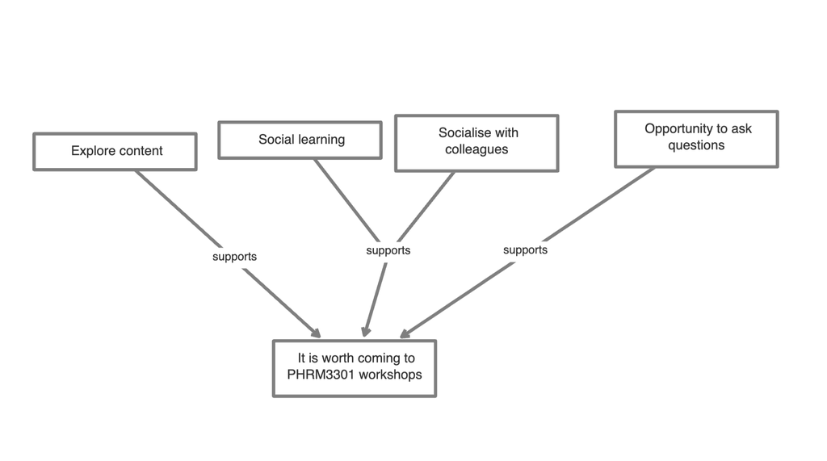

An example argument map

The following paragraph is from the introduction to Wagenlehner et al. (2024). Map out the argument for assessing cefepime-taniborbactam in a randomized trial:

> Cefepime, a broad-spectrum, fourth-generation cephalosporin, is used to treat such infections [i.e. complicated UTIs].[7] Resistance to cefepime has increased with the spread of extended-spectrum $\beta$-lactamase (ESBL) and carbapenemase enzymes.[7,8] Taniborbactam (formerly VNRX-5133) is a bicyclic boronate $\beta$-lactamase inhibitor with potent, selective, direct inhibitory activity against Ambler class A, B, C, and D enzymes, including prevalent serineand metallo-$\beta$-lactamases.[9,10] The cefepime-taniborbactam combination is active in vitro against most isolates of carbapenem-resistant Enterobacterales species, multidrug-resistant Pseudomonas aeruginosa, and Enterobacterales species and P. aeruginosa organisms that are resistant to both ceftolozane–tazobactam and ceftazidime-avibactam.[11-14] Cefepime–taniborbactam has shown in vivo efficacy against cefepime- and carbapenem-resistant Enterobacterales species and against P. aeruginosa.[15-17] Cefepime–taniborbactam has shown an acceptable side-effect profile in healthy volunteers; both cefepime and taniborbactam have well-matched plasma pharmacokinetics with greater than 80% renal elimination.[18-20]

Use https://reasons.io/ or draw it on a page (a worked example for argument mapping is provided [here](https://reasons.io/learn/01)).

## References

Wagenlehner, Florian M., Leanne B. Gasink, Paul C. McGovern, Greg Moeck, Patrick McLeroth, MaryBeth Dorr, Aaron Dane, and Tim Henkel. 2024. “Cefepime–Taniborbactam in Complicated Urinary Tract Infection.” *New England Journal of Medicine* 390 (7): 611–22. https://doi.org/10.1056/NEJMoa2304748.

[^1]: Limiting ourselves to the abstract is often fine for a first-pass at determining the PICO. Keep in mind that it has limitations, and that once we have the first draft of the PICO we would need to read targetted sections of the paper to flesh out/confirm the key details.